# World Food Facts

## Importing the data

El objetivo de este ejercicio es analizar la cantidad de azúcar en diferentes productos. Para comenzar vamos a proceder a cargar los datos pero en este caso en lugar de hacer uso de la función **read.csv()** vamos hacer uso de la función **fread()** del paquete **data.table**. Los datos serán almacenados en el formato datatble, pero sin embargo, para poder trabajar igual que con un dataframe podemos convertirlos a tipo dataframe.

```r
#Cargamos el paquete
library(data.table)
#Hacemos la lectura de los datos haciendo uso de la función fread
dt_food <- fread("food.csv")
#Pasamos de tipo datable a tipo dataframe
df_food <- data.frame(dt_food)
```

## Examining the data

Como es usual lo primero que debemos de hacer cuando nos llega un nuevo conjunto de datos a nuestro poder, ver que pinta tienen estos datos.

```r
#Vemos las primeras observaciones de los datos
head(df_food)
```

|  | V1 | code | url | creator | created_t | created_datetime | last_modified_t | last_modified_datetime | product_name | generic_name | quantity | packaging | packaging_tags | brands | brands_tags | categories | categories_tags | categories_en | origins | origins_tags | manufacturing_places | manufacturing_places_tags | labels | labels_tags | labels_en | emb_codes | emb_codes_tags | first_packaging_code_geo | cities | … |
| --- | --- | --- | --- | --- | --- | --- | --- | --- | --- | --- | --- | --- | --- | --- | --- | --- | --- | --- | --- | --- | --- | --- | --- | --- | --- | --- | --- | --- | --- | --- |
| 1 | 1 | 100030 | http://world-en.openfoodfacts.org/product/3222475745867/confiture-de-fraise-fraise-des-bois-au-sucre-de-canne-casino-delices | sebleouf | 1424747544 | 2015-02-24T03:12:24Z | 1438445887 | 2015-08-01T16:18:07Z | Confiture de fraise fraise des bois au sucre de canne |  | 265 g | Bocal,Verre | bocal,verre | Casino Délices | casino-delices | Aliments et boissons à base de végétaux,Aliments d'origine végétale,Aliments à base de fruits et de légumes,Petit-déjeuners,Produits à tartiner,Fruits et produits dérivés,Pâtes à tartiner végétaux,Pro… | en:plant-based-foods-and-beverages,en:plant-based-foods,en:fruits-and-vegetables-based-foods,en:breakfasts,en:spreads,en:fruits-based-foods,en:plant-based-spreads,en:sweet-spreads,en:fruit-preserves,e… | Plant-based foods and beverages,Plant-based foods,Fruits and vegetables based foods,Breakfasts,Spreads,Fruits based foods,Plant-based spreads,Sweet spreads,Fruit preserves,Jams,Fruit jams,Berry jams,S… |  |  | France | france |  |  |  | EMB 78015 | emb-78015 | 48.983333,2.066667 | NA | … |
| 2 | 2 | 100050 | http://world-en.openfoodfacts.org/product/5410976880110/guylian-sea-shells-selection | foodorigins | 1450316429 | 2015-12-17T01:40:29Z | 1450817956 | 2015-12-22T20:59:16Z | Guylian Sea Shells Selection |  | 375g | Plastic,Box | plastic,box | Guylian | guylian | Chocolate | en:sugary-snacks,en:chocolates | Sugary snacks,Chocolates |  |  | Belgium | belgium |  |  |  |  |  |  | NA | … |
| 3 | 3 | 100079 | http://world-en.openfoodfacts.org/product/3264750423503/pates-de-fruits-aromatisees-jacquot | domdom26 | 1428674916 | 2015-04-10T14:08:36Z | 1428739289 | 2015-04-11T08:01:29Z | Pâtes de fruits aromatisées | Pâtes de fruits | 1 kg | Carton,plastique | carton,plastique | Jacquot | jacquot | pâtes de fruits | en:plant-based-foods-and-beverages,en:plant-based-foods,en:fruits-and-vegetables-based-foods,en:sugary-snacks,en:confectioneries,en:fruits-based-foods,en:fruit-pastes | Plant-based foods and beverages,Plant-based foods,Fruits and vegetables based foods,Sugary snacks,Confectioneries,Fruits based foods,Fruit pastes |  |  |  |  |  |  |  |  |  |  | NA | … |
| 4 | 4 | 100094 | http://world-en.openfoodfacts.org/product/8006040247001/nata-vegetal-a-base-de-soja-valsoia | javichu | 1420416591 | 2015-01-05T00:09:51Z | 1420417876 | 2015-01-05T00:31:16Z | Nata vegetal a base de soja &quot;Valsoia&quot; | Nata vegetal a base de soja | 200 ml | Tetra Brik | tetra-brik | Valsoia,//Propiedad de://,Valsoia S.p.A. | valsoia,propiedad-de,valsoia-s-p-a | Alimentos y bebidas de origen vegetal,Alimentos de origen vegetal,Natas vegetales,Natas vegetales a base de soja para cocinar,Natas vegetales para cocinar | en:plant-based-foods-and-beverages,en:plant-based-foods,en:plant-based-creams,en:plant-based-creams-for-cooking,en:soy-based-creams-for-cooking | Plant-based foods and beverages,Plant-based foods,Plant-based creams,Plant-based creams for cooking,Soy-based creams for cooking |  |  | Italia | italia | Vegetariano,Vegano,Sin gluten,Sin OMG,Sin lactosa | en:vegetarian,en:vegan,en:gluten-free,en:no-gmos,en:no-lactose | Vegetarian,Vegan,Gluten-free,No GMOs,No lactose |  |  |  | NA | … |
| 5 | 5 | 100124 | http://world-en.openfoodfacts.org/product/8480000340764/semillas-de-girasol-con-cascara-tostadas-aguasal-hacendado | javichu | 1420501121 | 2015-01-05T23:38:41Z | 1445700917 | 2015-10-24T15:35:17Z | Semillas de girasol con cáscara tostadas aguasal | Semillas de girasol con cáscara tostadas aguasal | 200 g | Bolsa de plástico,Envasado en atmósfera protectora | bolsa-de-plastico,envasado-en-atmosfera-protectora | Hacendado,//Propiedad de://,Mercadona S.A. | hacendado,propiedad-de,mercadona-s-a | Semillas de girasol y derivados, Semillas, Semillas de girasol, Semillas de girasol con cáscara, Semillas de girasol tostadas, Semillas de girasol con cáscara tostadas, Semillas de girasol con cáscara… | en:plant-based-foods-and-beverages,en:plant-based-foods,en:seeds,en:sunflower-seeds-and-their-products,en:sunflower-seeds,en:roasted-sunflower-seeds,en:unshelled-sunflower-seeds,en:roasted-unshelled-s… | Plant-based foods and beverages,Plant-based foods,Seeds,Sunflower seeds and their products,Sunflower seeds,Roasted sunflower seeds,Unshelled sunflower seeds,Roasted unshelled sunflower seeds,es:Semill… | Argentina | argentina | Beniparrell,Valencia (provincia),Comunidad Valenciana,España | beniparrell,valencia-provincia,comunidad-valenciana,espana | Vegetariano,Vegano,Sin gluten | en:vegetarian,en:vegan,en:gluten-free | Vegetarian,Vegan,Gluten-free | ES 21.016540/V EC,ENVASADOR:,IMPORTACO S.A. | es-21-016540-v-ec,envasador,importaco-s-a |  | NA | … |
| 6 | 6 | 100136 | http://world-en.openfoodfacts.org/product/0087703177727/soft-drink | foodorigins | 1437983923 | 2015-07-27T07:58:43Z | 1445577476 | 2015-10-23T05:17:56Z | Soft Drink |  |  |  |  |  |  |  |  |  | South Korea | south-korea | South Korea | south-korea |  |  |  |  |  |  | NA | … |

```r
#Vemos la estructura de los datos
str(df_food)
```

```
'data.frame':   1500 obs. of  160 variables:
 $ V1                                        : int  1 2 3 4 5 6 7 8 9 10 ...
 $ code                                      : int  100030 100050 100079 100094 100124 100136 100194 100221 100257 100258 ...
 $ url                                       : chr  "http://world-en.openfoodfacts.org/product/3222475745867/confiture-de-fraise-fraise-des-bois-au-sucre-de-canne-casino-delices" "http://world-en.openfoodfacts.org/product/5410976880110/guylian-sea-shells-selection" "http://world-en.openfoodfacts.org…
 $ creator                                   : chr  "sebleouf" "foodorigins" "domdom26" "javichu" ...
 $ created_t                                 : int  1424747544 1450316429 1428674916 1420416591 1420501121 1437983923 1442420988 1435686217 1436991777 1400516512 ...
 $ created_datetime                          : chr  "2015-02-24T03:12:24Z" "2015-12-17T01:40:29Z" "2015-04-10T14:08:36Z" "2015-01-05T00:09:51Z" ...
 $ last_modified_t                           : int  1438445887 1450817956 1428739289 1420417876 1445700917 1445577476 1442420988 1451405288 1436991779 1437236856 ...
 $ last_modified_datetime                    : chr  "2015-08-01T16:18:07Z" "2015-12-22T20:59:16Z" "2015-04-11T08:01:29Z" "2015-01-05T00:31:16Z" ...
 $ product_name                              : chr  "Confiture de fraise fraise des bois au sucre de canne" "Guylian Sea Shells Selection" "Pâtes de fruits aromatisées" "Nata vegetal a base de soja &quot;Valsoia&quot;" ...
 $ generic_name                              : chr  "" "" "Pâtes de fruits" "Nata vegetal a base de soja" ...
 $ quantity                                  : chr  "265 g" "375g" "1 kg" "200 ml" ...
 $ packaging                                 : chr  "Bocal,Verre" "Plastic,Box" "Carton,plastique" "Tetra Brik" ...
 $ packaging_tags                            : chr  "bocal,verre" "plastic,box" "carton,plastique" "tetra-brik" ...
 $ brands                                    : chr  "Casino Délices" "Guylian" "Jacquot" "Valsoia,//Propiedad de://,Valsoia S.p.A." ...
```

[output cut: 86 more lines]

```r
#Hacemos un summary de los datos
summary(df_food)
```

```
       V1              code            url              creator            created_t         created_datetime
 Min.   :   1.0   Min.   :100030   Length:1500        Length:1500        Min.   :1.332e+09   Length:1500
 1st Qu.: 375.8   1st Qu.:124974   Class :character   Class :character   1st Qu.:1.394e+09   Class :character
 Median : 750.5   Median :149514   Mode  :character   Mode  :character   Median :1.425e+09   Mode  :character
 Mean   : 750.5   Mean   :149613                                         Mean   :1.414e+09
 3rd Qu.:1125.2   3rd Qu.:174506                                         3rd Qu.:1.436e+09
 Max.   :1500.0   Max.   :199880                                         Max.   :1.453e+09
 last_modified_t     last_modified_datetime product_name       generic_name         quantity          packaging
 Min.   :1.340e+09   Length:1500            Length:1500        Length:1500        Length:1500        Length:1500
 1st Qu.:1.424e+09   Class :character       Class :character   Class :character   Class :character   Class :character
 Median :1.437e+09   Mode  :character       Mode  :character   Mode  :character   Mode  :character   Mode  :character
 Mean   :1.430e+09
 3rd Qu.:1.446e+09
 Max.   :1.453e+09
 packaging_tags        brands          brands_tags         categories        categories_tags    categories_en
 Length:1500        Length:1500        Length:1500        Length:1500        Length:1500        Length:1500
 Class :character   Class :character   Class :character   Class :character   Class :character   Class :character
 Mode  :character   Mode  :character   Mode  :character   Mode  :character   Mode  :character   Mode  :character



   origins          origins_tags       manufacturing_places manufacturing_places_tags    labels          labels_tags
 Length:1500        Length:1500        Length:1500          Length:1500               Length:1500        Length:1500
 Class :character   Class :character   Class :character     Class :character          Class :character   Class :character
 Mode  :character   Mode  :character   Mode  :character     Mode  :character          Mode  :character   Mode  :character



  labels_en          emb_codes         emb_codes_tags     first_packaging_code_geo  cities        cities_tags
 Length:1500        Length:1500        Length:1500        Length:1500              Mode:logical   Length:1500
 Class :character   Class :character   Class :character   Class :character         NA's:1500      Class :character
 Mode  :character   Mode  :character   Mode  :character   Mode  :character                        Mode  :character



 purchase_places       stores           countries         countries_tags     countries_en       ingredients_text
 Length:1500        Length:1500        Length:1500        Length:1500        Length:1500        Length:1500
 Class :character   Class :character   Class :character   Class :character   Class :character   Class :character
 Mode  :character   Mode  :character   Mode  :character   Mode  :character   Mode  :character   Mode  :character

```

[output cut: 135 more lines]

```
 ph_100g        fruits_vegetables_nuts_100g collagen_meat_protein_ratio_100g   cocoa_100g   chlorophyl_100g
 Mode:logical   Min.   : 2.00               Min.   :12.00                    Min.   :30     Mode:logical
 NA's:1500      1st Qu.:11.25               1st Qu.:13.50                    1st Qu.:47     NA's:1500
                Median :42.00               Median :15.00                    Median :60
                Mean   :36.88               Mean   :15.67                    Mean   :57
                3rd Qu.:52.25               3rd Qu.:17.50                    3rd Qu.:70
                Max.   :80.00               Max.   :20.00                    Max.   :81
 carbon_footprint_100g nutrition_score_fr_100g nutrition_score_uk_100g
 Min.   : 12.00        Min.   :-12.000         Min.   :-12.000
 1st Qu.: 97.42        1st Qu.:  1.000         1st Qu.:  0.000
 Median :182.85        Median :  7.000         Median :  6.000
 Mean   :131.18        Mean   :  7.941         Mean   :  7.631
 3rd Qu.:190.78        3rd Qu.: 15.000         3rd Qu.: 16.000
 Max.   :198.70        Max.   : 28.000         Max.   : 28.000
 [ reached getOption("max.print") -- omitted 1 row ]
```

## Inspecting variables

En este caso las funciones **summary()** y **str()** debido a la gran cantidad de variables que disponemos no son del todo las más adecuadas para ver como están estructurados nuestros datos. El paquete **dplyr** dispone de la función **glimpse()** que nos retorna casi la misma información que **str()** pero en un formato más adecuado

```r
#Cargamos dplyr
library(dplyr)
#Hacemos uso de la función glimpse
glimpse(df_food)
```

```
Observations: 1,500
Variables: 160
$ V1                                         <int> 1, 2, 3, 4, 5, 6, 7, 8, 9, 10, 11, 12, 13, 14, 15, 16, 17, 18, 19, 20,...
$ code                                       <int> 100030, 100050, 100079, 100094, 100124, 100136, 100194, 100221, 100257...
$ url                                        <chr> "http://world-en.openfoodfacts.org/product/3222475745867/confiture-de-...
$ creator                                    <chr> "sebleouf", "foodorigins", "domdom26", "javichu", "javichu", "foodorig...
$ created_t                                  <int> 1424747544, 1450316429, 1428674916, 1420416591, 1420501121, 1437983923...
$ created_datetime                           <chr> "2015-02-24T03:12:24Z", "2015-12-17T01:40:29Z", "2015-04-10T14:08:36Z"...
$ last_modified_t                            <int> 1438445887, 1450817956, 1428739289, 1420417876, 1445700917, 1445577476...
$ last_modified_datetime                     <chr> "2015-08-01T16:18:07Z", "2015-12-22T20:59:16Z", "2015-04-11T08:01:29Z"...
$ product_name                               <chr> "Confiture de fraise fraise des bois au sucre de canne", "Guylian Sea ...
$ generic_name                               <chr> "", "", "Pâtes de fruits", "Nata vegetal a base de soja", "Semillas de...
$ quantity                                   <chr> "265 g", "375g", "1 kg", "200 ml", "200 g", "", "150 ml", "250 g", "50...
$ packaging                                  <chr> "Bocal,Verre", "Plastic,Box", "Carton,plastique", "Tetra Brik", "Bolsa...
$ packaging_tags                             <chr> "bocal,verre", "plastic,box", "carton,plastique", "tetra-brik", "bolsa...
```

[output cut: 147 more lines]

## Removing duplicate info

Tenemos una gran cantidad de información duplicada, es por esto que vamos a proceder a eliminar todas esas variables que no nos aportan ningún tipo de información.

```r
#Nos creamos el vector de las columnas duplicadas
duplicates <- c(4, 6, 11, 13, 15, 17, 18, 20, 22,
                24, 25, 28, 32, 34, 36, 38, 40,
                44, 46, 48, 51, 54, 65, 158)
#Eliminamos las columnas duplicadas
df_food2 <- df_food[,-duplicates]
```

## Removing useless info

Además de información duplicada, nuestro conjunto de datos contiene columnas que no son de utilidad. Por ejemplo, las primeras columnas contienen códigos de productos, además existen algunas columnas que su descripción no deja claro que tipo de información contiene, todas estas columnas deben de ser eliminadas.

```r
#Definimos un vector con las columnas que no aportan ningún tipo de información
useless <- c(1, 2, 3, 32:41)
#Eliminamos dichas columnas
df_food3 <- df_food2[,-useless]
```

## Finding columns

A continución vamos a proceder a seleccionar aquellas columnas que en su nombre llevan “100g” que son aquellas columnas que nos indican la cantidad de azúcar por cada cien gramos de ciertos productos.

```r
#Cargamos la librería
library(stringr)
#Obtenemos los índices de las columnas que contienen las palabra 100g
indices <- str_detect(names(df_food3), "100g")
summary(df_food3[,indices])
```

```
 energy_from_fat_100g    fat_100g      saturated_fat_100g butyric_acid_100g caproic_acid_100g caprylic_acid_100g
 Min.   :   0.00      Min.   :  0.00   Min.   : 0.000     Mode:logical      Mode:logical      Mode:logical
 1st Qu.:  35.98      1st Qu.:  0.90   1st Qu.: 0.200     NA's:1500         NA's:1500         NA's:1500
 Median : 237.00      Median :  6.00   Median : 1.700
 Mean   : 668.41      Mean   : 13.39   Mean   : 4.874
 3rd Qu.: 974.00      3rd Qu.: 20.00   3rd Qu.: 6.500
 Max.   :2900.00      Max.   :100.00   Max.   :57.000
 NA's   :1486         NA's   :708      NA's   :797
 capric_acid_100g lauric_acid_100g myristic_acid_100g palmitic_acid_100g stearic_acid_100g arachidic_acid_100g
 Mode:logical     Mode:logical     Mode:logical       Mode:logical       Mode:logical      Mode:logical
 NA's:1500        NA's:1500        NA's:1500          NA's:1500          NA's:1500         NA's:1500





 behenic_acid_100g lignoceric_acid_100g cerotic_acid_100g montanic_acid_100g melissic_acid_100g monounsaturated_fat_100g
 Mode:logical      Mode:logical         Mode:logical      Mode:logical       Mode:logical       Min.   : 0.00
 NA's:1500         NA's:1500            NA's:1500         NA's:1500          NA's:1500          1st Qu.: 3.87
                                                                                                Median : 9.50
                                                                                                Mean   :19.77
                                                                                                3rd Qu.:29.00
                                                                                                Max.   :75.00
                                                                                                NA's   :1465
 polyunsaturated_fat_100g omega_3_fat_100g alpha_linolenic_acid_100g eicosapentaenoic_acid_100g docosahexaenoic_acid_100g
 Min.   : 0.400           Min.   : 0.033   Min.   :0.0800            Min.   :0.721              Min.   :1.09
 1st Qu.: 1.653           1st Qu.: 1.300   1st Qu.:0.0905            1st Qu.:0.721              1st Qu.:1.09
 Median : 3.900           Median : 3.000   Median :0.1010            Median :0.721              Median :1.09
 Mean   : 9.986           Mean   : 3.726   Mean   :0.1737            Mean   :0.721              Mean   :1.09
 3rd Qu.:12.700           3rd Qu.: 3.200   3rd Qu.:0.2205            3rd Qu.:0.721              3rd Qu.:1.09
 Max.   :46.200           Max.   :12.400   Max.   :0.3400            Max.   :0.721              Max.   :1.09
 NA's   :1464             NA's   :1491     NA's   :1497              NA's   :1499               NA's   :1499
 omega_6_fat_100g linoleic_acid_100g arachidonic_acid_100g gamma_linolenic_acid_100g dihomo_gamma_linolenic_acid_100g
 Min.   :0.25     Min.   :0.5000     Mode:logical          Mode:logical              Mode:logical
 1st Qu.:0.25     1st Qu.:0.5165     NA's:1500             NA's:1500                 NA's:1500
 Median :0.25     Median :0.5330
 Mean   :0.25     Mean   :0.5330
 3rd Qu.:0.25     3rd Qu.:0.5495
 Max.   :0.25     Max.   :0.5660
 NA's   :1499     NA's   :1498
```

[output cut: 65 more lines]

```
 Mode:logical   Mode:logical   Mode:logical   Min.   : 2.00               Min.   :12.00                    Min.   :30
 NA's:1500      NA's:1500      NA's:1500      1st Qu.:11.25               1st Qu.:13.50                    1st Qu.:47
                                              Median :42.00               Median :15.00                    Median :60
                                              Mean   :36.88               Mean   :15.67                    Mean   :57
                                              3rd Qu.:52.25               3rd Qu.:17.50                    3rd Qu.:70
                                              Max.   :80.00               Max.   :20.00                    Max.   :81
                                              NA's   :1470                NA's   :1497                     NA's   :1491
 chlorophyl_100g nutrition_score_fr_100g nutrition_score_uk_100g
 Mode:logical    Min.   :-12.000         Min.   :-12.000
 NA's:1500       1st Qu.:  1.000         1st Qu.:  0.000
                 Median :  7.000         Median :  6.000
                 Mean   :  7.941         Mean   :  7.631
                 3rd Qu.: 15.000         3rd Qu.: 16.000
                 Max.   : 28.000         Max.   : 28.000
                 NA's   :825             NA's   :825
```

## Replacing missing values

Podemos ver en el summary que el número de NA es bastante elevado la variables “sugars_100g”. Debemos de cambiar estos valores que son NA por cero y tras esto representar un histograma.

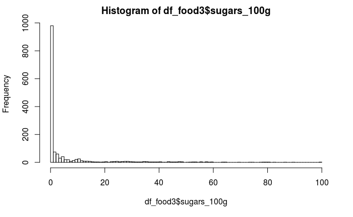

```r
#Detectamos donde están los ceros
missing <- is.na(df_food3$sugars_100g)
#Cambiamos los NA por ceros
df_food3$sugars_100g[missing] <- 0
#Representamos el histograma con breaks = 100
hist(df_food3$sugars_100g, breaks = 100)
```

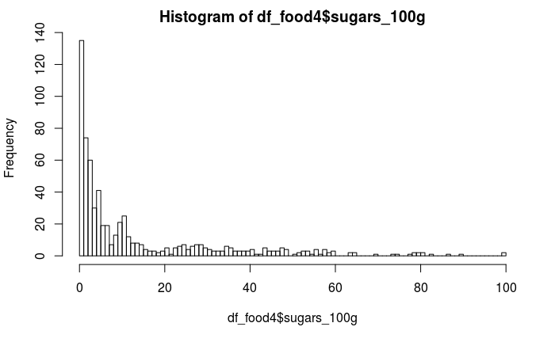

```r
#Eliminamos los ceros
df_food4 <- df_food3[df_food3$sugars_100g > 0 ,]
#Representamos le histograma
hist(df_food4$sugars_100g, breaks = 100)
```

## Dealing with messy data

Finalmente nuestro objetivo es conocer cuantos de estos alimentos vienen en un contenido de plástico. Sin embargo la variable que nos indica esto, se encuentra en varios idiomas. Sin embargo la raíz de la palabra es la misma para los idiomas en los que aparece, en este caso la raíz es “plasti”.

```r
#Encontramos las palabras que contienen "plasti"
plastic <- str_detect(df_food3$packaging, "plasti")
#Vemos el número de alimentos que cumplen que vienen embasados en plástico
sum(plastic)
```

```
[1] 232
```